# Recommendations for Criteo case study

Vladimir Mikheev

06 07 2021

# 1. Timing

## 1.1. Hour

Let’s observe at what time sales occur

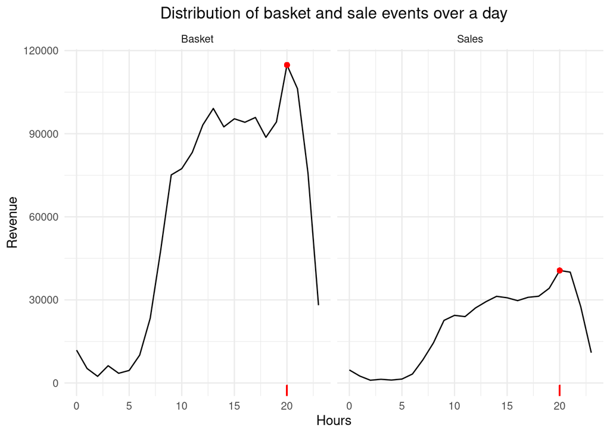

The purchasing spans from 9 o’clock to 23 o’clock. The most popular time for sales is 20 o’clock.

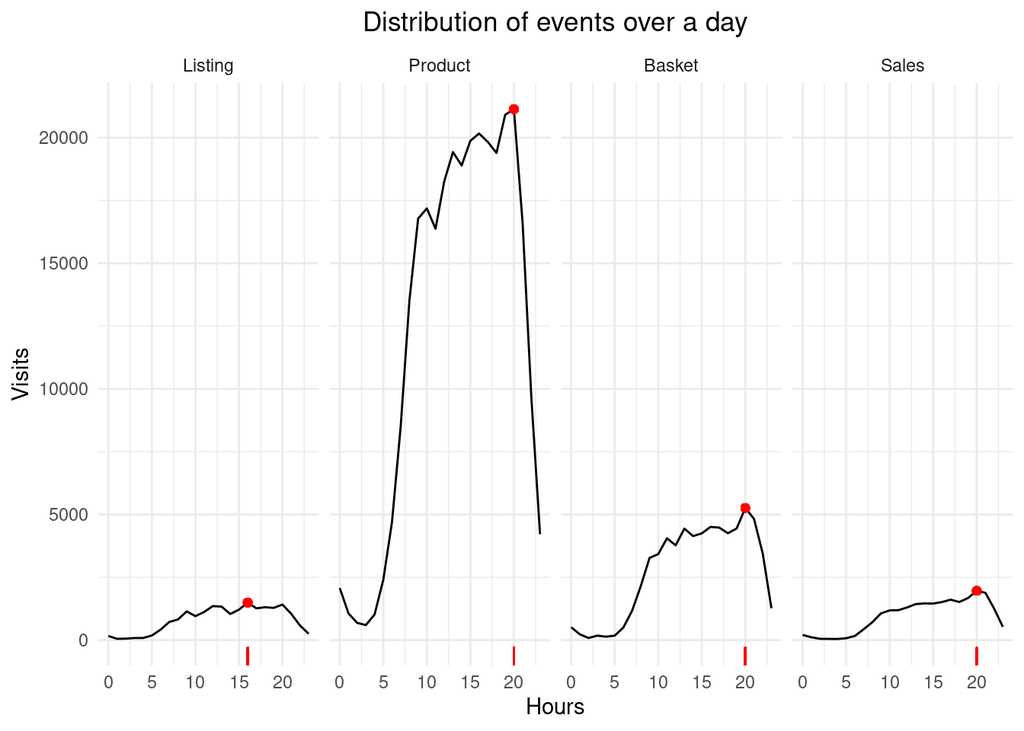

Product visiting, basketing and purchasing happens mostly at 20 o’clock, while listing is uniformly distrusted across day with maximum at 16 o’clock.

**Recommendation:** the perfect timing for advertisment is between 16 to 20 o’clock

## 1.2. Day of week

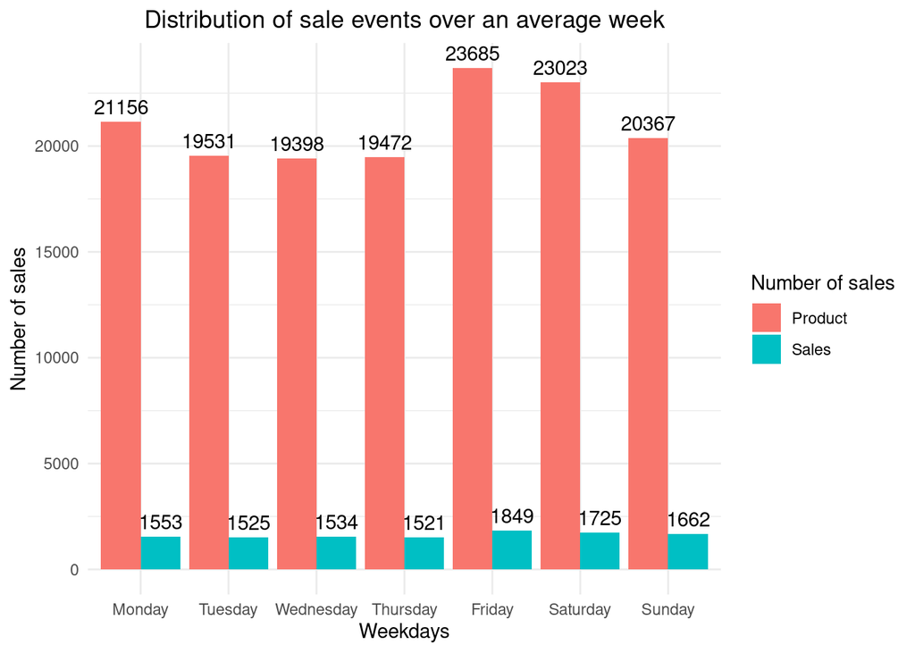

Does these differences between days are significant?

```
## Chi2(1) |     p |                                                       Method
## ------------------------------------------------------------------------------
## 1.53    | 0.215 | Pearson's Chi-squared test with Yates' continuity correction
```

```
## Chi2(1)  |      p |                                                       Method
## --------------------------------------------------------------------------------
## 9.91e-28 | > .999 | Pearson's Chi-squared test with Yates' continuity correction
```

**Recommendation:**

1. The most sailing days are Friday, Saturday and Sunday;
2. However, chi-square demonstrates that there is no significant difference between these days, so we can favor any of these days for advetisement campaign.

# 2. Browser

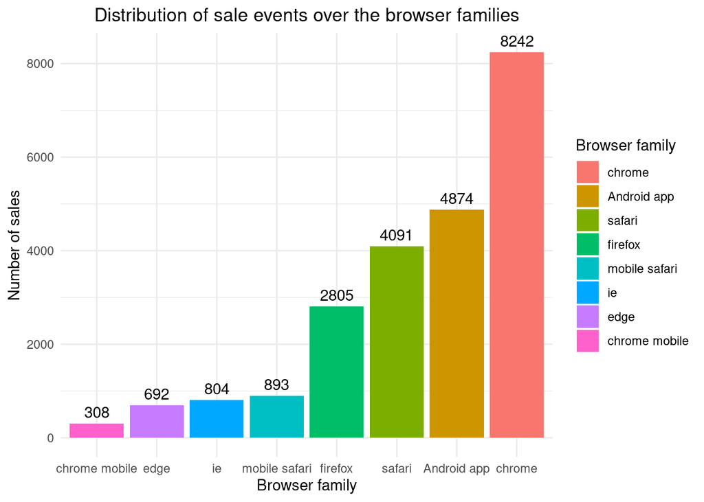

Let’s also observe browser usage through different device groups.

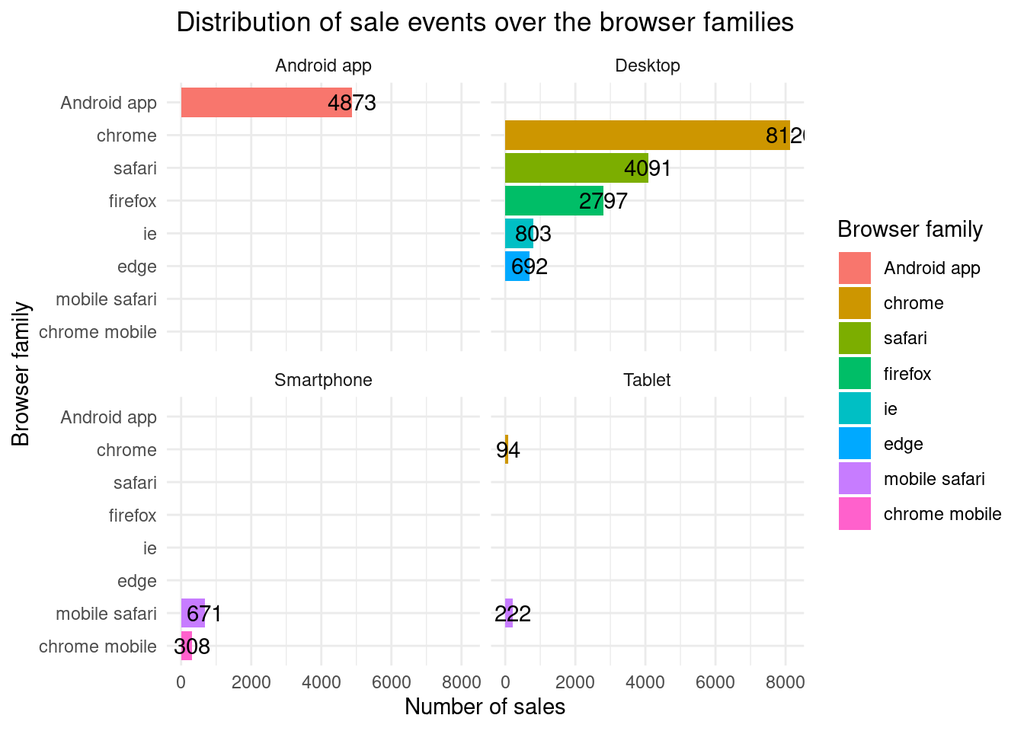

**Recommendation:**

Different browsers render content in their own way. So during advertisement campaign company should adjust to the following browsers as soon as they affect the majority of sales:

- Chrome, Safari and Firefox for desktop;
- Mobile Safari and Chrome Mobile for smartphones;
- Mobile Safari and Chrome for Tablets.

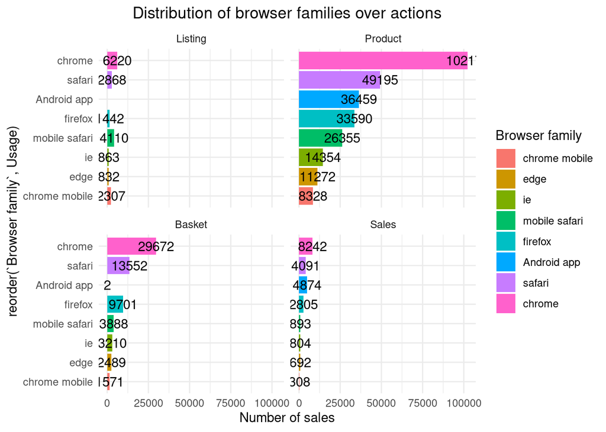

# 2. User location

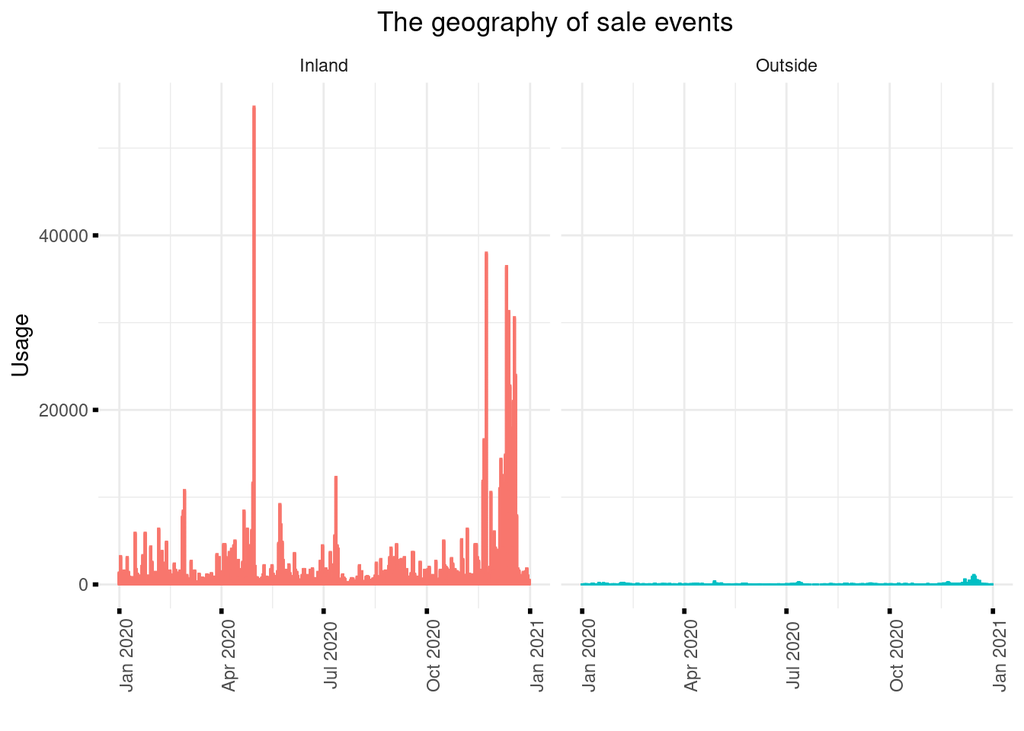

|  | Usage |  |  |
| --- | --- | --- | --- |
| Predictors | Estimates | CI | p |
| (Intercept) | 66.18 | 65.49 – 66.87 | **<0.001** |
| User location [Outside] | -56.96 | -59.20 – -54.72 | **<0.001** |
| Observations | 18000 |  |  |
| R<sup>2</sup> / R<sup>2</sup> adjusted | 0.122 / 0.121 |  |  |

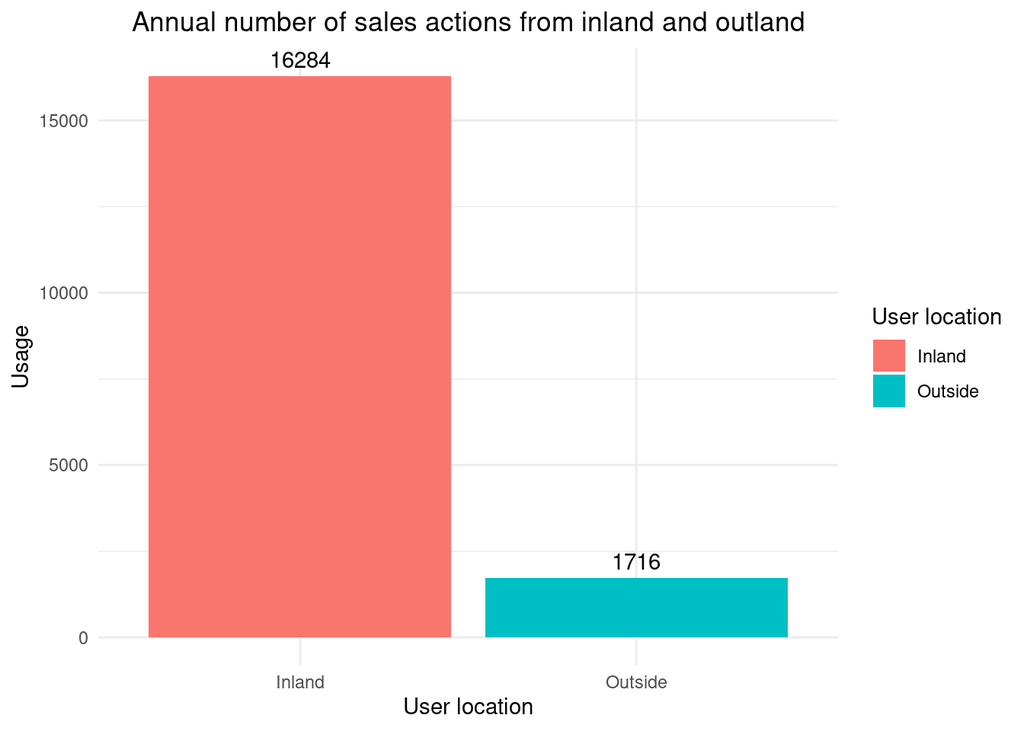

**Recommendation:** only 10 % of sales occur from outside and mean daily, so outside advertisment should not be a main focus of a campaign.

# 3. Existing client

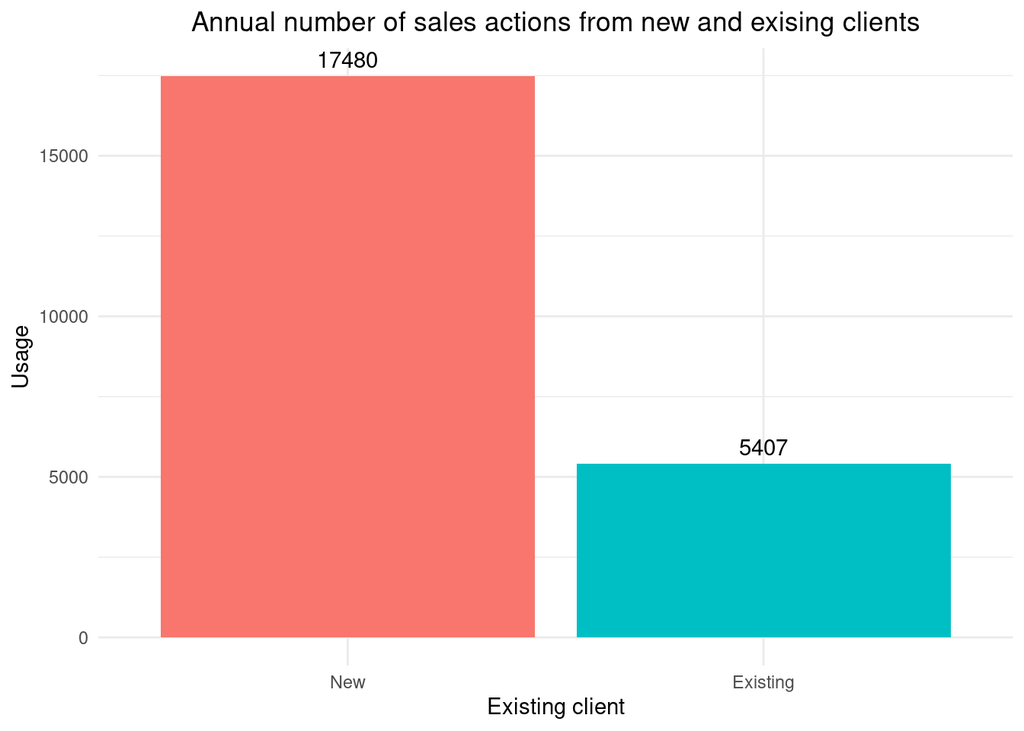

| Existing client | Total Revenue | Mean Revenue | Median Revenue | Mean Product Quantity |
| --- | --- | --- | --- | --- |
| 0 | 357527 | 20.45349 | 17 | 1.041419 |
| 1 | 115416 | 21.34566 | 17 | 1.039393 |

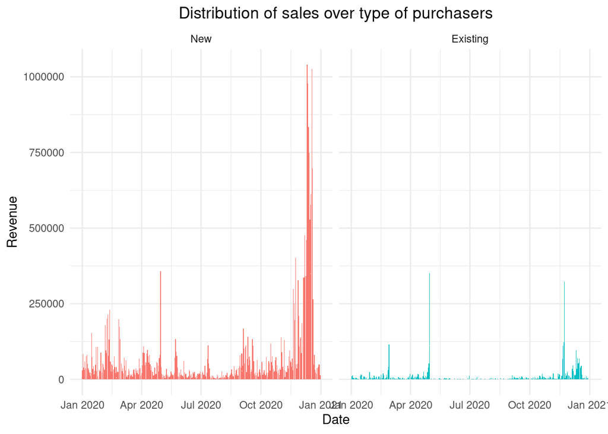

New clients buy significantly more

# 3. Product category

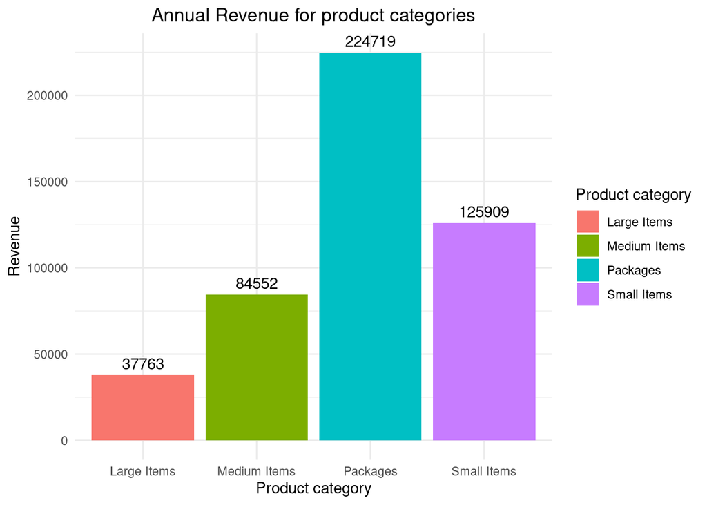

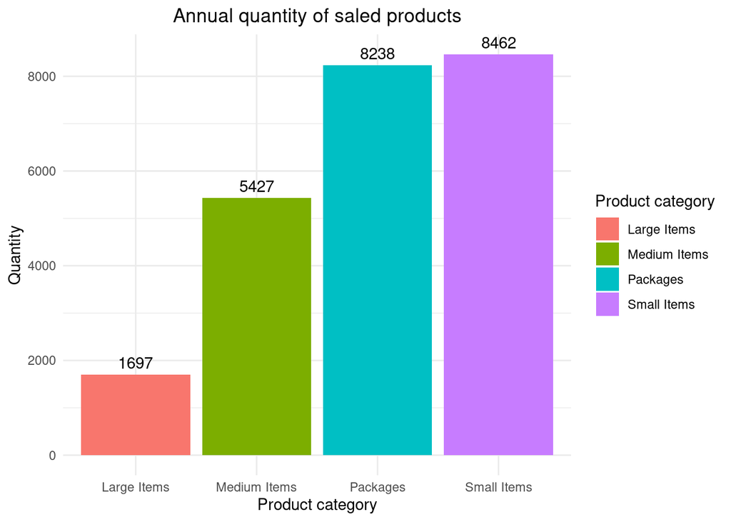

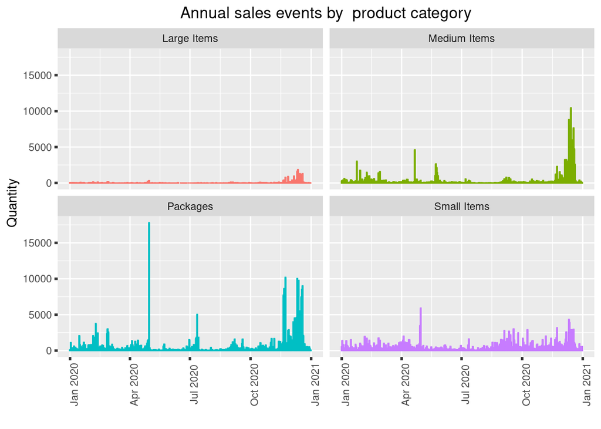

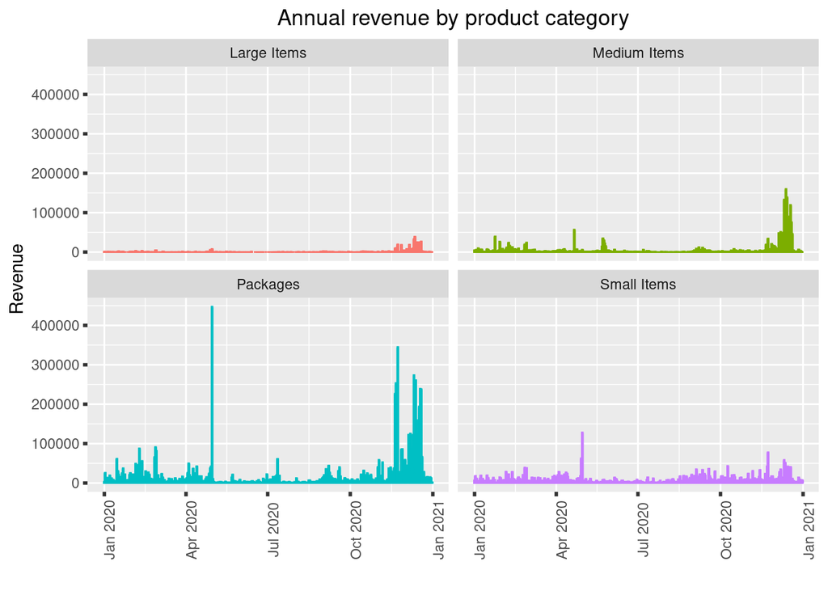

**Recommendations:**

1. packages and small item were saled in the same quantity, but revenue from packages is highest among all products and by two times higher than from small items
2. Advertising of two leading products, packages and small items, should give the highest revenue.
3. In November-December promotion of packages and medium items is preferable.
4. In April promotion of packages and small items is preferable.